# Tugas-Pertemuan-5

Elardian Putera Ramadhan (G1401231042)

2025-10-02

## **1. Persiapan dan Pemisahan Data (Train & Test)**

Langkah pertama adalah menyiapkan data deret waktu Anda dan membaginya menjadi 80% data *training* dan 20% data *testing*.

```r
# Menggunakan library yang relevan
library(forecast)
library(tseries)
```

```r
library(ggplot2)
data <- read.csv("C:/Users/Putera Ramadhan/OneDrive/Documents/IPB University/Semester 5/(MPDW) Metode Peramalan Deret Waktu/UTS/Praktikum/MPDW/Pertemuan 1/Data/Reversed Bitcoin Historical Price.csv")
data$Date <- as.Date(data$Date, format="%m/%d/%Y")
data$Price <- as.numeric(gsub(",", "", data$Price))
data_subset <- data[253:378, ]

# Membuat objek time series (ts) dari kolom Price
# Frekuensi 52 untuk data mingguan.
# Kita tentukan start date dari data_subset$Date[1] yaitu "2020-11-01" (minggu ke-44 tahun 2020)
harga_ts <- ts(data_subset$Price, start = c(2020, 44), frequency = 52)

# Menghitung titik pembagian data
split_point <- floor(0.8 * length(harga_ts))

# Memisahkan data train dan test
train_data <- window(harga_ts, end = time(harga_ts)[split_point])
test_data <- window(harga_ts, start = time(harga_ts)[split_point + 1])

# Menampilkan panjang data masing-masing
cat("Panjang Data Asli   :", length(harga_ts), "\n")
```

```
## Panjang Data Asli   : 126
```

```r
cat("Panjang Data Train  :", length(train_data), "\n")
```

```
## Panjang Data Train  : 100
```

```r
cat("Panjang Data Test   :", length(test_data), "\n")
```

```
## Panjang Data Test   : 26
```

## **2. Pengecekan Kestasioneran dalam Rataan (Mean) pada Data Train**

Kita akan menggunakan dua metode: visualisasi (plot deret waktu dan ACF) dan uji statistik formal (Augmented Dickey-Fuller Test).

### **a. Analisis Visual**

**Plot Deret Waktu:**

Plot data train untuk melihat apakah ada tren (pola naik atau turun) yang jelas.

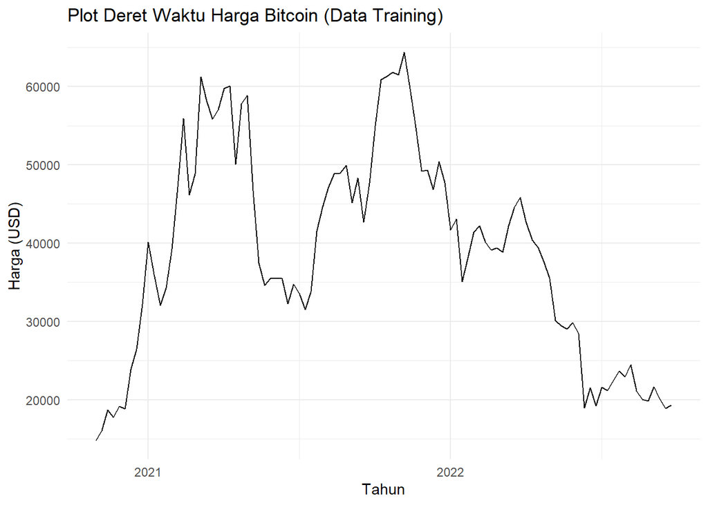

```r
autoplot(train_data, main = "Plot Deret Waktu Harga Bitcoin (Data Training)",
         xlab="Tahun", ylab="Harga (USD)") +
  theme_minimal()
```

**Interpretasi:** Plot tersebut menunjukkan data yang **tidak stasioner** karena adanya **pola tren naik-turun yang sangat jelas**, yang berarti nilai rata-rata data tidak konstan melainkan terus berubah seiring waktu.

**Plot ACF (Autocorrelation Function):**

Plot ACF menunjukkan korelasi antara observasi saat ini dengan observasi sebelumnya (lag).

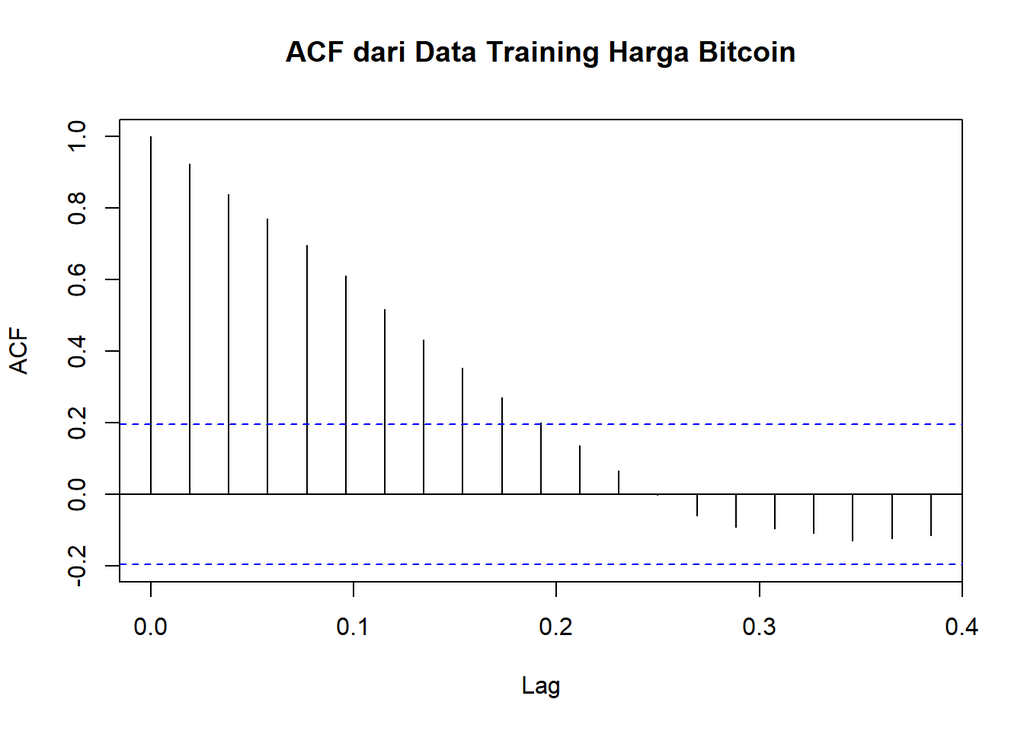

```r
acf(train_data, main = "ACF dari Data Training Harga Bitcoin")
```

**Interpretasi:** Plot ACF menunjukkan **penurunan yang sangat lambat (slow decay)**. Korelasi pada lag-lag awal sangat tinggi dan turun secara linear. Ini adalah ciri khas dari data yang memiliki tren atau **tidak stasioner dalam rataan**.

### **b. Uji Statistik (Augmented Dickey-Fuller Test)**

Uji ADF digunakan untuk menguji hipotesis adanya *unit root*.

- $H_0$: Data tidak stasioner (memiliki *unit root*).
- $H_1$: Data stasioner.

Kita menolak $H_0$ jika **p-value < 0.05**.

```r
adf.test(train_data)
```

```
##
##  Augmented Dickey-Fuller Test
##
## data:  train_data
## Dickey-Fuller = -2.7008, Lag order = 4, p-value = 0.2863
## alternative hypothesis: stationary
```

**Interpretasi:** Didapatkan **p-value = 0.2863**, yang jauh lebih besar dari 0.05. Artinya, kita **gagal menolak** $H_0$. Ini secara statistik mengonfirmasi bahwa data *training* **tidak stasioner dalam rataan**.

## **3. Penanganan Ketidakstasioneran dalam Rataan**

Untuk mengatasi tren, kita akan melakukan **differencing** orde 1 pada data *training*.

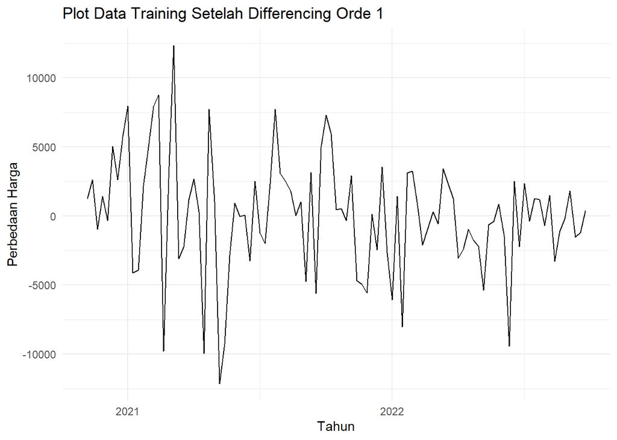

```r
# Melakukan differencing orde 1
train_data_diff1 <- diff(train_data, differences = 1)

# Plot data setelah differencing
autoplot(train_data_diff1, main = "Plot Data Training Setelah Differencing Orde 1",
         xlab="Tahun", ylab="Perbedaan Harga") +
  theme_minimal()
```

### **Verifikasi Ulang Kestasioneran Rataan**

Sekarang, kita uji kembali data yang sudah di-*differencing*.

- **Plot ACF:**

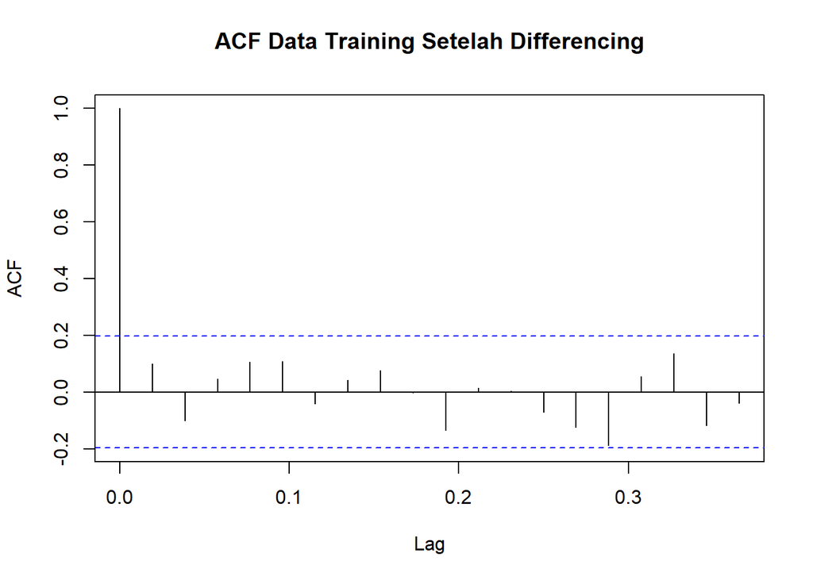

  ```r
  acf(train_data_diff1, main = "ACF Data Training Setelah Differencing")
  ```

  **Interpretasi:** Plot ACF sekarang menunjukkan penurunan yang cepat (cut off) setelah lag 0. Ini menandakan data sudah stasioner dalam rataan.
- **Uji ADF:**

  ```r
  adf.test(train_data_diff1)
  ```

  ```
  ##
  ##  Augmented Dickey-Fuller Test
  ##
  ## data:  train_data_diff1
  ## Dickey-Fuller = -3.7744, Lag order = 4, p-value = 0.023
  ## alternative hypothesis: stationary
  ```

  **Interpretasi:** **p-value = 0.023** (atau bisa lebih kecil tergantung *lag order*), yang sekarang lebih kecil dari 0.05. Kita **berhasil menolak** $H_0$.

**Kesimpulan:** Data `train_data_diff1` sekarang sudah **stasioner dalam rataan**.

## **4. Pengecekan Kestasioneran dalam Ragam (Variance)**

Sekarang kita periksa apakah ragam dari data yang sudah stasioner rataan (`train_data_diff1`) bersifat konstan.

### **a. Analisis Visual**

Lihat kembali plot data setelah di-*differencing*. Perhatikan apakah lebar fluktuasi data sama sepanjang waktu.

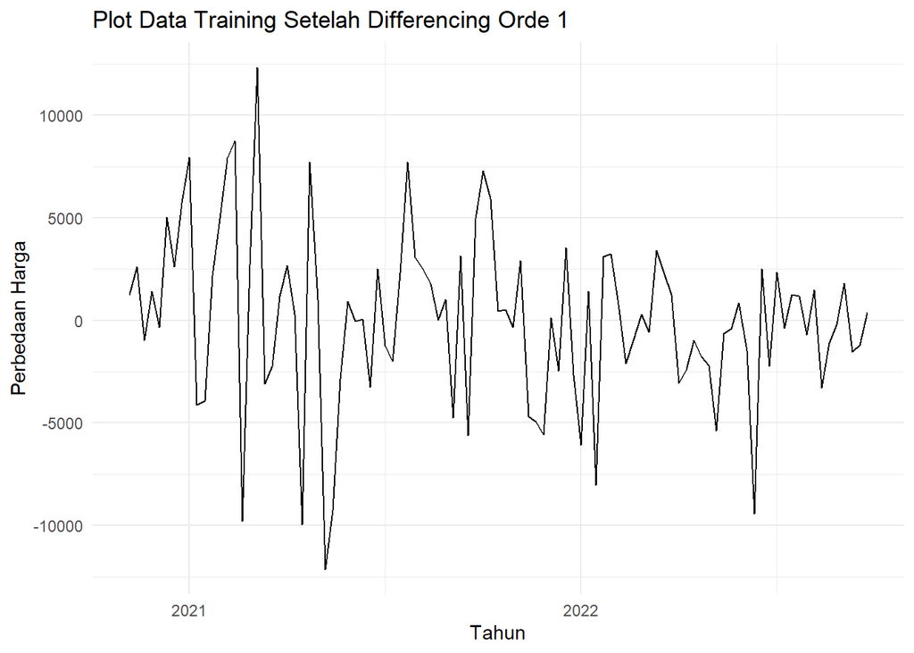

```r
autoplot(train_data_diff1, main = "Plot Data Training Setelah Differencing Orde 1",
         xlab="Tahun", ylab="Perbedaan Harga") +
  theme_minimal()
```

**Interpretasi:** Secara visual, terlihat bahwa fluktuasi (volatilitas) harga di beberapa bagian tampak lebih besar dibandingkan bagian lainnya. Ini mengindikasikan kemungkinan adanya **ketidakstasioneran dalam ragam**.

### **b. Uji Statistik (Box-Cox Plot)**

Transformasi Box-Cox membantu menstabilkan ragam. Untuk menemukan parameter transformasi ($\lambda$) yang paling sesuai, kita bisa memvisualisasikannya dengan plot Box-Cox yang menunjukkan nilai *Log-Likelihood* untuk berbagai kandidat $\lambda$. Nilai $\lambda$ yang optimal adalah yang memberikan nilai *Log-Likelihood* tertinggi.

```r
# Memanggil library tambahan untuk plot Box-Cox
library(MASS)
train_data_positive <- train_data_diff1 + abs(min(train_data_diff1)) + 1
```

**Plot Box-Cox untuk Menentukan Lambda**

Plot di bawah ini akan menunjukkan nilai Log-Likelihood pada sumbu Y untuk rentang nilai λ pada sumbu X. Puncak dari kurva ini adalah nilai λ optimal.

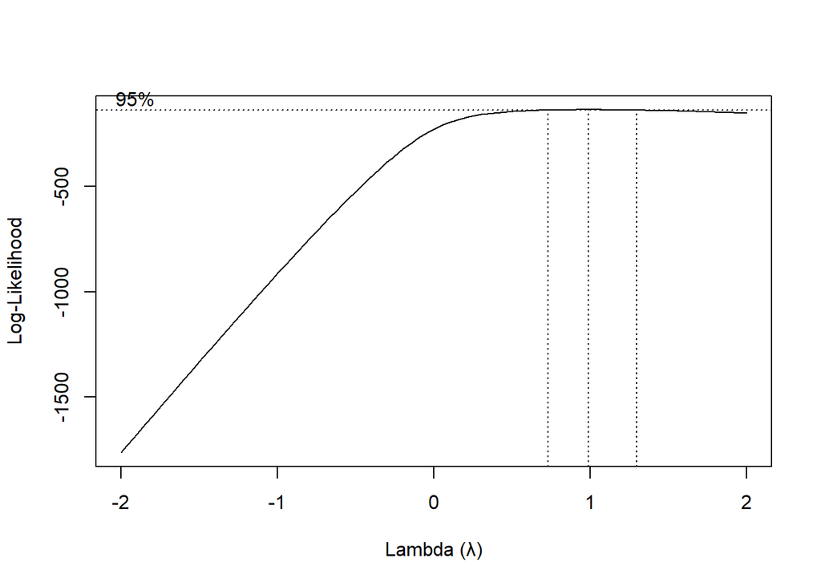

```r
# Membuat Plot Box-Cox
boxcox(train_data_positive ~ 1,
       xlab="Lambda (λ)",
       ylab="Log-Likelihood")
```

**Lambda Optimum dan Selang Kepercayaan 95%**

Sekarang akan dihitung nilai pastinya menggunakan fungsi `BoxCox.lambda()` dari paket `forecast`, sekaligus mencari selang kepercayaan 95% untuk nilai lambda tersebut. Selang kepercayaan ini memberi kita rentang nilai $\lambda$ yang paling mungkin.

```r
# Mencari lambda optimal menggunakan paket forecast (lebih praktis)
lambda_opt <- BoxCox.lambda(train_data_positive)
cat("Nilai Lambda Optimal:", lambda_opt, "\n")
```

```
## Nilai Lambda Optimal: 1
```

```r
# Untuk mencari selang kepercayaan, kita bisa menggunakan kembali hasil dari fungsi boxcox()
bc <- boxcox(train_data_positive ~ 1, plotit = FALSE) # Menjalankan tanpa membuat plot lagi
lambda_ci <- data.frame(lambda = bc$x, loglik = bc$y)

# Menentukan batas bawah dan atas untuk selang kepercayaan 95%
ci_boundary <- max(lambda_ci$loglik) - 0.5 * qchisq(0.95, 1)
ci_lower <- min(lambda_ci$lambda[lambda_ci$loglik >= ci_boundary])
ci_upper <- max(lambda_ci$lambda[lambda_ci$loglik >= ci_boundary])

cat("Selang Kepercayaan 95% untuk Lambda: (", round(ci_lower, 2), ",", round(ci_upper, 2), ")\n")
```

```
## Selang Kepercayaan 95% untuk Lambda: ( 0.8 , 1.2 )
```

Gambar di atas menunjukkan nilai $\lambda$ optimum (rounded value) sebesar **1** dan selang kepercayaan 95% nilai memiliki batas bawah **0.8** dan batas atas **1.2**. Selang tersebut memuat nilai satu sehingga dapat dikatakan bahwa `train_data_positive` stasioner dalam ragam.

## **Kesimpulan Akhir**

Berdasarkan analisis kestasioneran pada data *training* harga Bitcoin, dapat disimpulkan bahwa:

1. Data asli terbukti **tidak stasioner dalam rataan** karena menunjukkan pola tren yang jelas, yang dikonfirmasi oleh plot ACF yang menurun lambat dan hasil uji ADF (p-value > 0.05).
2. Penanganan melalui **differencing orde 1** berhasil mengatasi masalah ini, menghasilkan data deret waktu yang **stasioner dalam rataan**, sebagaimana dibuktikan oleh plot ACF yang *cut-off* dan hasil uji ADF (p-value < 0.05).
3. Pengecekan kestasioneran dalam ragam pada data yang telah di-*differencing* melalui uji Box-Cox menunjukkan nilai lambda optimal adalah **1**, dengan selang kepercayaan 95% **(0.8, 1.2)**. Karena rentang ini **memuat nilai 1**, maka secara statistik **tidak ada cukup bukti untuk menolak bahwa ragamnya stasioner**. Oleh karena itu, transformasi untuk menstabilkan ragam tidak diperlukan.

Dengan demikian, data `train_data_diff1` adalah data final yang telah **stasioner baik dalam rataan maupun ragam** dan siap digunakan untuk tahap pemodelan deret waktu selanjutnya.